# Sentiment Analysis of IMDB Movie Reviews

Dylan Smith

2026-01-15

# Introduction

Introduction Sentiment analysis has become increasingly important due to the growth in user-generated content and feedback on digital platforms (Pang & Lee, 2008). Examples include social media, online reviews, and e-commerce sites, meaning that organisations now have access to vast amounts of public opinion data. This information provides insight into customer satisfaction and potential future consumer behaviour, allowing marketing strategies and business decisions to be more informed. However, the only efficient and cost-effective way to perform this task is through machine learning techniques, as manual analysis would be inconsistent, time-consuming, and inefficient at scale. This motivates the need to investigate predictive modelling approaches for automated sentiment classification. Although we have more data than ever before, transferring this data into a clear positive or negative opinion based on the textual content present remains a challenging task due to how complex language can be, and the interpretation can be subjective. This can be particularly relevant in movie reviews due to sarcasm, informal wording, and varying levels of writing style and ability, which may skew sentiment polarity. Therefore, this study aims to investigate whether sentiment polarity in movie reviews can be predicted accurately using supervised machine learning techniques due to the IMDB dataset having sentiment labels. The focus will be on optimising model performance and evaluating how effectively the model generalises to new unseen data. Overfitting and underfitting will be examined throughout to ensure the model can be reused reliably for other sentiment analysis. To address this aim, the following research questions are investigated: 1. To what extent can supervised learning accurately classify positive and negative sentiment in IMDB movie reviews? 2. How do different machine learning models compare in terms of accuracy, precision, recall, and F1-score when classifying sentiment? 3. To what extent does hyperparameter tuning improve predictive performance and reduce overfitting in sentiment classification models? This study uses the IMDB Large Movie Review Dataset, which contains 50,000 reviews evenly balanced between negative and positive sentiment (Maas et al., 2011). This dataset was chosen over alternatives because its size is sufficient for model training, validation, and evaluation, without being excessively large or computationally demanding like the Amazon review dataset. In addition, the IMDB reviews are already pre-labelled, making them well-suited for supervised classification. The dataset has also been widely used in prior sentiment analysis research, supporting reproducibility and meaningful comparison with existing work. Previous studies have shown that traditional machine learning models, such as logistic regression and support vector machines, demonstrate robust performance on sentiment classification tasks when combined with TF-IDF or bag-of-words features (Pang & Lee, 2008; Maas et al., 2011). This study contributes to this field by comparing supervised models on the IMDB dataset and evaluating their performance and generalisation to unseen reviews. Methodology 2.1 pre-processing Data pre-processing is the foundation of any machine learning experiment. It transforms raw data into structured features with a purpose that can be analysed and modelled effectively. Issues such as bias, variance and sparsity can be evaluated better with the new perspectives of the data. Text data is sensitive to noise due to each word becoming a feature, so dimensionality is affected by small issues. The raw IMDb reviews contained various forms of noise, such as HTML tags, incoherent casing, and punctuation, which are natural in user-generated text. Without correct cleaning, these issues would distort the tokenisation, vocabulary, and overall results. Cleaning will also help control the dimensionality of the text, since it is a key variable for text analysis and having unnecessary unique words would inflate feature space. Reducing said dimensionality would help the models focus on the meaningful patterns which are important in deciphering whether a sentiment is positive or negative and, in turn, generalise future unseen reviews. With too many meaningless features, it will cause instability in models. In the first stage of pre-processing, I performed several cleaning operations to standardise the text. To ensure all changes were applied correctly, I copied the dataset to review raw. HTML tags appeared in the reviews because the data was scraped directly from the IMDB website. I removed these tags to prevent inflated vocabulary and noise, so high-variance models would not be distracted by formatting artefacts. I converted all text to lowercase to avoid duplicate features, since models might otherwise treat ‘The’ and ‘the’ as different words. After testing the most popular vocabulary, I found ‘br’ was a top term, meaning it had not been fully removed. I then removed it manually to reduce high-frequency noise, improving TF-IDF weighting. I removed punctuation, which has negligible effect on sentiment, to cut meaningless tokens and reduce dimensionality, thus preventing overfitting. Lastly, I removed extra whitespace created during previous cleaning steps. These actions make IF-IDF results more reliable and less affected by formatting noise. Next, I measured the number of words in each review to see if sentiment differed between. There was an insignificant difference in mean and median, which suggests that this is not a meaningful feature and shows there is no length-based bias between them. It is important to make sure this was not a factor since the model would have learnt “long = positive or negative” instead of true sentiment cues. I then tokenised the dataset into individual words and removed stop words due to them being meaningless noise, carrying no sentiment value, and only increasing dimensionality. I noticed some words like “don” once “don’t” and “vet” once “I’ve,” I kept them in since I did not want to underfit and remove useful sentiment cues. I visually checked, and the vocabulary was reflecting meaningful terms. Next, to check sparsity, I examined vocabulary size. There were ~100k distinct words. I initially thought this was exceedingly high. After further analysis, I found 37% of those words were unique. The vocabulary size was normal for user-generated text. These rare words increase sparsity and dimensionality. Luckily, TF-IDF down weights rare words, so they will not heavily affect the model later. This reduces variance and stabilises the model during training. I thought about phrases such as “very good” and came to bigrams, which may be a stronger feature than individual words. I extracted consecutive word pairs from each review. I separated them into two individual words, then stripped them of stop words again, then recombined and separated the most popular in each sentiment. Bigrams not only give an informative analysis of the patterns of phrases but also stops models from oversimplifying text and improves generalisation by learning meaningful phrasing. I wanted to get a sense of how the text was structured, so I looked at Zipf’s law of a few words appearing frequently while a considerable number appear sparsely. I plotted the text, and it indeed followed the law. This reinforced the advantageous use of TF-IDF due to the overused and barely used words. This also highlights why a simple Bag-of-Words model would struggle, as it would be heavily affected by this imbalance and show high variance.

# 2.1 Data Pre-processing

```r
library(tidyverse) #toolkit
library(textclean) #text cleaning
library(tidytext) # tokenisation


# Import dataset to imdb
imdb <- read_csv("IMDB Dataset.csv")
# Seeing structure on dataset
glimpse(imdb)
```

```
## Rows: 50,000
## Columns: 2
## $ review    <chr> "One of the other reviewers has mentioned that after watchin…
## $ sentiment <chr> "positive", "positive", "positive", "negative", "positive", …
```

# CLEANING

```r
imdb <- imdb %>%
  mutate(
    review_raw= review, #keep a save of original text for comparison
    review = replace_html(review) , #remove html tags
    review = str_to_lower(review),
#put to lowercase so all standarised
    review = str_replace_all( review, "\\bbr\\b", " "), #came back and removed "br" cus it showed in the top words
    review = str_replace_all(review, "[^a-z\\s]"," "),
#remove characters thats not letters like  , . ? !
    review = str_squish(review)
  )

imdb %>%
  select( review_raw, review,sentiment) %>%
  head() # verifying new review with all changes comapared to raw.
```

```
## # A tibble: 6 × 3
##   review_raw                                                    review sentiment
##   <chr>                                                         <chr>  <chr>
## 1 "One of the other reviewers has mentioned that after watchin… one o… positive
## 2 "A wonderful little production. <br /><br />The filming tech… a won… positive
## 3 "I thought this was a wonderful way to spend time on a too h… i tho… positive
## 4 "Basically there's a family where a little boy (Jake) thinks… basic… negative
## 5 "Petter Mattei's \"Love in the Time of Money\" is a visually… pette… positive
## 6 "Probably my all-time favorite movie, a story of selflessnes… proba… positive
```

# LENGTHS

```r
#word could for each review
imdb <-imdb %>%
  mutate(review_length = str_count(review, "\\S+"))
#preview the reviews lengths alongside the sentiment
imdb %>%
  select(review,sentiment, review_length)  %>%
  head()
```

```
## # A tibble: 6 × 3
##   review                                                 sentiment review_length
##   <chr>                                                  <chr>             <int>
## 1 one of the other reviewers has mentioned that after w… positive            313
## 2 a wonderful little production the filming technique i… positive            160
## 3 i thought this was a wonderful way to spend time on a… positive            167
## 4 basically there s a family where a little boy jake th… negative            133
## 5 petter mattei s love in the time of money is a visual… positive            228
## 6 probably my all time favorite movie a story of selfle… positive            123
```

```r
imdb %>% #comapring review length mean between the two sentiments
  group_by( sentiment) %>%
  summarise(

    mean_length= mean(review_length),
    median_length = median(review_length) ,
    sd_length = sd(review_length)
  )#found the mean length is only 3 words difference meaning lnegth isnt a meaningful feature
```

```
## # A tibble: 2 × 4
##   sentiment mean_length median_length sd_length
##   <chr>           <dbl>         <dbl>     <dbl>
## 1 negative         233.          176.      167.
## 2 positive         236.          175       180.
```

# TOKENISING

```r
# Tokenise so i can just reuse instead of doing everytime
tokens <- imdb %>%
  unnest_tokens(word, review)

tokens_clean <- tokens %>%
  anti_join(stop_words, by = "word")
```

# COMMON WORDS

```r
tokens_clean  %>%
  #remove the useful stop words using anyi_join since carry no sentiment

# then count the remianing relevant w ords
  count(word,  sort = TRUE) %>%
  head(20)
```

```
## # A tibble: 20 × 2
##    word           n
##    <chr>      <int>
##  1 movie      87972
##  2 film       79708
##  3 time       25109
##  4 story      23121
##  5 bad        18473
##  6 people     18188
##  7 don        17623
##  8 movies     15309
##  9 characters 14456
## 10 watch      13946
## 11 character  13905
## 12 films      13755
## 13 love       13009
## 14 plot       12987
## 15 life       12919
## 16 acting     12867
## 17 scene      10968
## 18 scenes     10482
## 19 ve         10241
## 20 real        9432
```

```r
tokens_clean %>%
#now sorting by sentiment

  count(sentiment , word , sort = TRUE) %>%
  group_by(sentiment) %>%
  slice_max(n, n = 15) #top 15 for each sentiment
```

```
## # A tibble: 30 × 3
## # Groups:   sentiment [2]
##    sentiment word       n
##    <chr>     <chr>  <int>
##  1 negative  movie  50118
##  2 negative  film   37597
##  3 negative  bad    14726
##  4 negative  time   12357
##  5 negative  don    10622
##  6 negative  story  10186
##  7 negative  people  9469
##  8 negative  movies  8313
##  9 negative  plot    8214
## 10 negative  acting  8087
## # ℹ 20 more rows
```

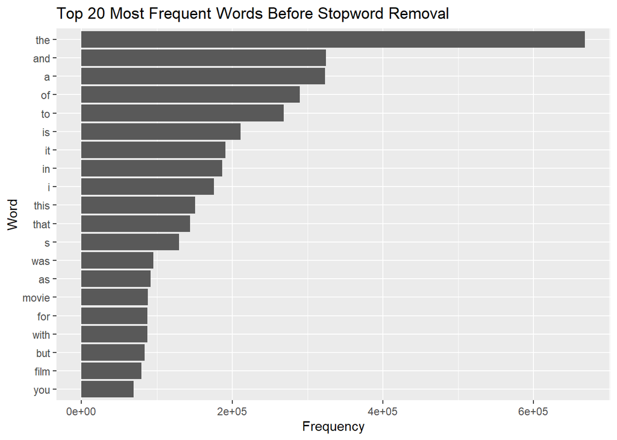

```r
library(ggplot2)

tokens %>%
  count(word, sort = TRUE) %>%
  slice_head(n = 20) %>%
  ggplot(aes(x = reorder(word, n), y = n)) +
  geom_col() +
  coord_flip() +
  labs(title = "Top 20 Most Frequent Words Before Stopword Removal",
       x = "Word",
       y = "Frequency")
```

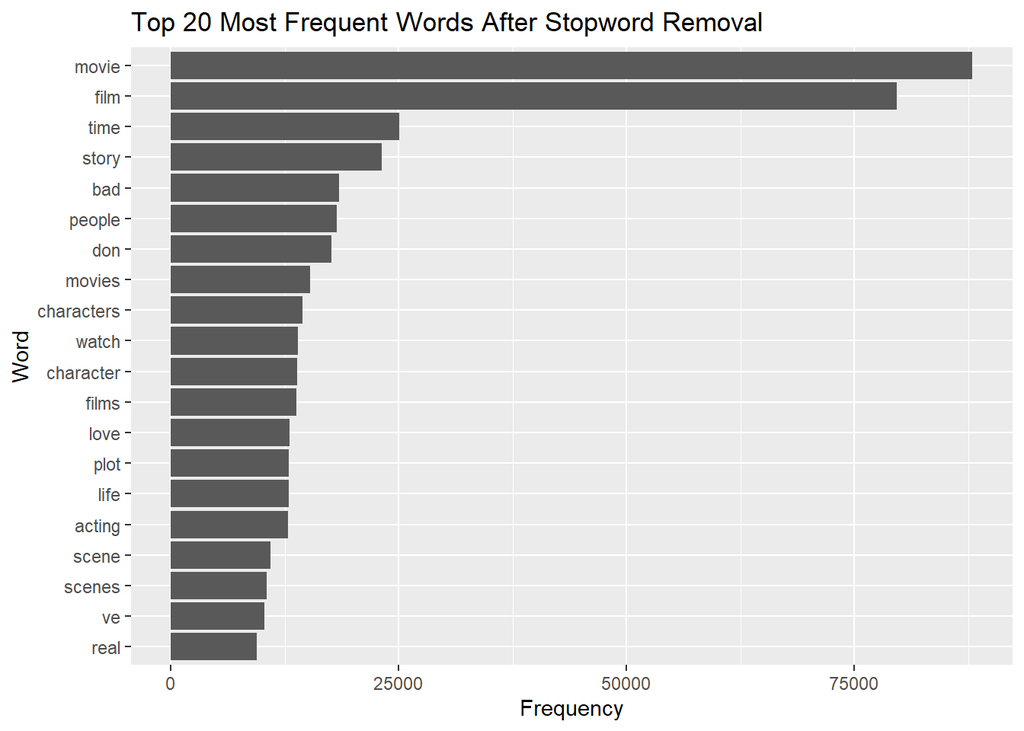

```r
# Top 20 most frequent words AFTER removing stopwords
tokens_clean %>%
  count(word, sort = TRUE) %>%
  slice_head(n = 20) %>%
  ggplot(aes(x = reorder(word, n), y = n)) +
  geom_col() +
  coord_flip() +
  labs(title = "Top 20 Most Frequent Words After Stopword Removal",
       x = "Word",
       y = "Frequency")
```

#brain storming thinking how sometimes terms like “not good” and stuff could misrepresent the data

# BIGRAMS

```r
# creating the two word bigrams and using imdb instead of tokens since need 2 words not single words
tokens_bigram <- imdb %>%
  unnest_tokens(bigram, review, token = "ngrams", n = 2) # makes a new column called bigram, with input column is review then the token n-grams is bigrams since i put n=2.

tokens_bigram %>%
  count(bigram, sort = TRUE) %>%
  head(20)
```

```
## # A tibble: 20 × 2
##    bigram         n
##    <chr>      <int>
##  1 of the     77358
##  2 in the     50489
##  3 it s       33765
##  4 this movie 31513
##  5 the film   26943
##  6 and the    26707
##  7 is a       26099
##  8 the movie  23942
##  9 to the     23741
## 10 to be      23491
## 11 this film  21832
## 12 it is      19903
## 13 this is    18648
## 14 on the     18009
## 15 in a       17620
## 16 don t      16983
## 17 it was     16912
## 18 one of     16255
## 19 for the    15950
## 20 with the   15776
```

# not really helpful stuff, i can instead combine bigram and sentiment. due to presence of stopwords making this useless.

```r
library(tidyr)

# seperating bigrams into two words
bigrams_separated<- tokens_bigram %>%
  separate(bigram, into=c("word1", "word2"), sep= " ")
# now making sure neither word is a stopword
bigrams_filtered <- bigrams_separated %>%
  filter(!word1 %in% stop_words$word,
         !word2 %in% stop_words$word)

#isnt clear which is for positive and nagetive. sentiment
```

```r
bigrams_filtered %>%
  unite( bigram, word1,word2, sep = " ")%>% # recombine making sure no stopwords
  count(sentiment, bigram, sort = TRUE) %>% # cont bigram frequency within each sentiment
  group_by(sentiment) %>%
  slice_max(n, n=15)
```

```
## # A tibble: 30 × 3
## # Groups:   sentiment [2]
##    sentiment bigram              n
##    <chr>     <chr>           <int>
##  1 negative  special effects  1442
##  2 negative  low budget       1221
##  3 negative  sci fi            770
##  4 negative  main character    696
##  5 negative  worst movie       694
##  6 negative  bad movie         684
##  7 negative  horror movie      651
##  8 negative  bad acting        605
##  9 negative  horror film       506
## 10 negative  real life         476
## # ℹ 20 more rows
```

# VOCABULARY

```r
tokens %>%
  distinct(word) %>%
  count(name = "vocab_size")
```

```
## # A tibble: 1 × 1
##   vocab_size
##        <int>
## 1      99420
```

```r
#counting each distinct word
```

#so the vocab size is ~ 100k which is 2x the amount of reviews. at first i didnt believe this how can there be so many unique words for a similar purpose like movie reviews.

```r
tokens %>%
  count(word) %>% #counting words which appear
  filter(n == 1) %>% #exactly one time
  count(name = "unique_word_count")
```

```
## # A tibble: 1 × 1
##   unique_word_count
##               <int>
## 1             37296
```

#this clarifies that ~37% are unique words.

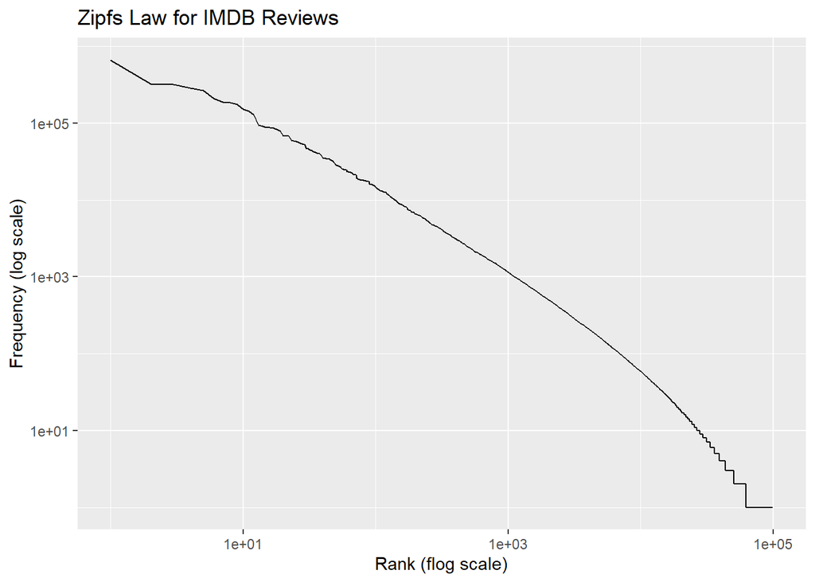

```r
#zipf law is the frequency of a small amount of words are used extremely frquency while more rare less frequent

freq <- tokens %>% # makes a pipeline from single word token dataframe
  count(word, sort = TRUE) %>% # counts each unique word appears
  mutate(rank = row_number()) #ranks each word as ##1 most frequenct word andd then 100k least

ggplot(freq, aes(rank, n)) + #creates a scatter plot
  geom_line() + # draws a line to each point
  scale_x_log10() + # put the x axis and y axis scale to log10()
  scale_y_log10() +
  labs(title = "Zipfs Law for IMDB Reviews",
       x = "Rank (flog scale)",
       y = "Frequency (log scale)")
```

2.2 Feauture Engineering

```r
#preparing for feature engineering and modeling

imdb <- imdb %>%
  mutate(
    rev_id = row_number(),        # each review has unqiue id now
    sentiment = factor(sentiment) # sentiment needs to be factor for future modelling
  )

# check if applied
imdb %>%
  select(rev_id , sentiment, review) %>%
  head()
```

```
## # A tibble: 6 × 3
##   rev_id sentiment review
##    <int> <fct>     <chr>
## 1      1 positive  one of the other reviewers has mentioned that after watching…
## 2      2 positive  a wonderful little production the filming technique is very …
## 3      3 positive  i thought this was a wonderful way to spend time on a too ho…
## 4      4 negative  basically there s a family where a little boy jake thinks th…
## 5      5 positive  petter mattei s love in the time of money is a visually stun…
## 6      6 positive  probably my all time favorite movie a story of selflessness …
```

```r
#confirmed each h
```

#attach rev_id to clean token

```r
imdb <- imdb %>%
  mutate(
    rev_id   = row_number(), #add unique id column
    sentiment = factor(sentiment) #makes sentiment a column
  )

imdb %>%
  select(rev_id, sentiment, review) %>%
  head()
```

```
## # A tibble: 6 × 3
##   rev_id sentiment review
##    <int> <fct>     <chr>
## 1      1 positive  one of the other reviewers has mentioned that after watching…
## 2      2 positive  a wonderful little production the filming technique is very …
## 3      3 positive  i thought this was a wonderful way to spend time on a too ho…
## 4      4 negative  basically there s a family where a little boy jake thinks th…
## 5      5 positive  petter mattei s love in the time of money is a visually stun…
## 6      6 positive  probably my all time favorite movie a story of selflessness …
```

# re token with id attached

```r
tokens <- imdb %>%
  select(rev_id, sentiment, review) %>%
  unnest_tokens(word, review)


tokens_clean <- tokens %>%
  anti_join(stop_words, by = "word")

tokens_clean %>%
  head()
```

```
## # A tibble: 6 × 3
##   rev_id sentiment word
##    <int> <fct>     <chr>
## 1      1 positive  reviewers
## 2      1 positive  mentioned
## 3      1 positive  watching
## 4      1 positive  oz
## 5      1 positive  episode
## 6      1 positive  ll
```

# remebered to add bigrams and we redo incorperting rev_id

```r
# 1. Create bigrams tied to each rev_id
tokens_bigram <- imdb %>%
  select(rev_id, review) %>%
  unnest_tokens(bigram, review, token = "ngrams", n = 2)

# 2. Split bigram into two words
bigrams_separated <- tokens_bigram %>%
  separate(bigram, into = c("word1", "word2"), sep = " ")

# 3. Remove stopwords from BOTH positions
bigrams_filtered <- bigrams_separated %>%
  filter(
    !word1 %in% stop_words$word,
    !word2 %in% stop_words$word
  )

# 4. Recombine word1 + word2 into a single token (bigram)
# Keep only (rev_id, word)
bigrams_ready <- bigrams_filtered %>%
  unite(word, word1, word2, sep = " ") %>%
  select(rev_id, word)

# Preview
head(bigrams_ready)
```

```
## # A tibble: 6 × 2
##   rev_id word
##    <int> <chr>
## 1      1 oz episode
## 2      1 unflinching scenes
## 3      1 faint hearted
## 4      1 drugs sex
## 5      1 called oz
## 6      1 oswald maximum
```

```r
library(dplyr)
library(tidytext)
library(Matrix)
# 1) Combine unigrams (tokens_clean) and bigrams (bigrams_ready)
tokens_uni <- tokens_clean %>%
  select(rev_id, word)

tokens_all <- bind_rows(
  tokens_uni,
  bigrams_ready
)

# 2) TF-IDF on unigrams + bigrams together
tfidf_all <- tokens_all %>%
  count(rev_id, word) %>%           # term frequency per review
  bind_tf_idf(word, rev_id, n)      # add tf, idf, tf-idf

# 3) Cast to sparse matrix for modelling
dtm_all <- tfidf_all %>%
  select(rev_id, word, tf_idf) %>%
  cast_sparse(rev_id, word, tf_idf)

dtm_all
```

```
## 50000 x 931163 sparse Matrix of class "dgCMatrix"
```

[output not shown]

[output not shown]

[output not shown]

[output cut: 7804 more lines]

[output not shown]

[output not shown]

[output cut: 6237 more lines]

```r
dim(dtm_all)
```

```
## [1]  50000 931163
```